# PEC1_Analisis Estadistico

## 3.3 *Variable Temperatura*

```
##       media  mediana media_winsorizada desviacion_tipica   varianza      IQR
## 1 0.4953848 0.498333         0.4971884          0.183051 0.03350767 0.318333
##     maximo    minimo        Q1        Q3
## 1 0.861667 0.0591304 0.3370835 0.6554165
```

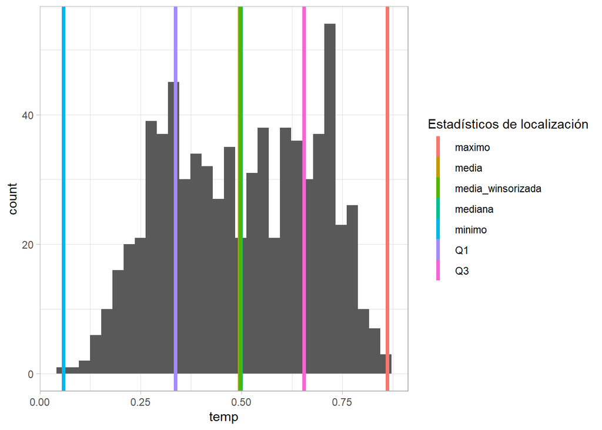

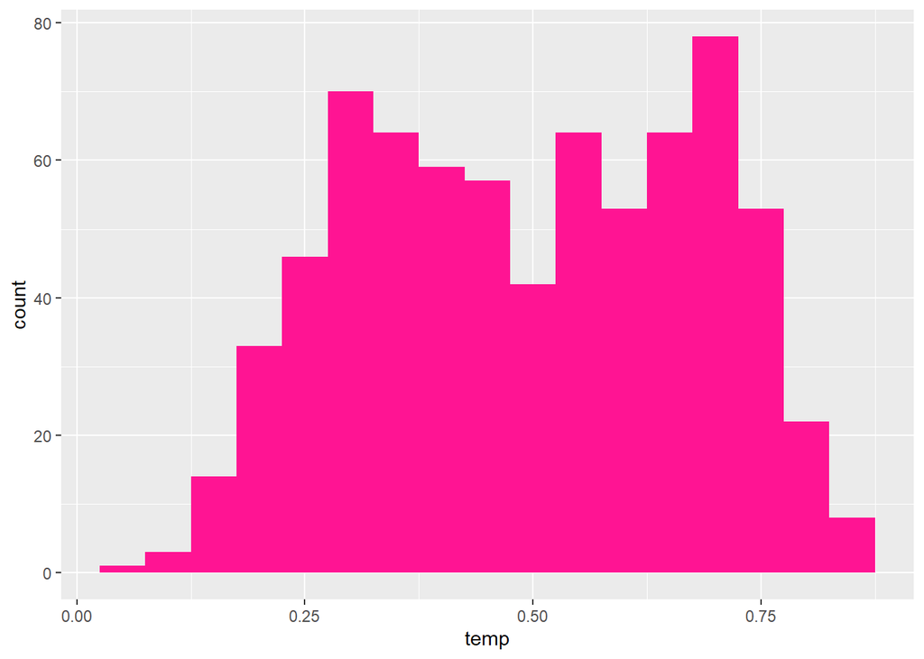

**Grafico Combinado**

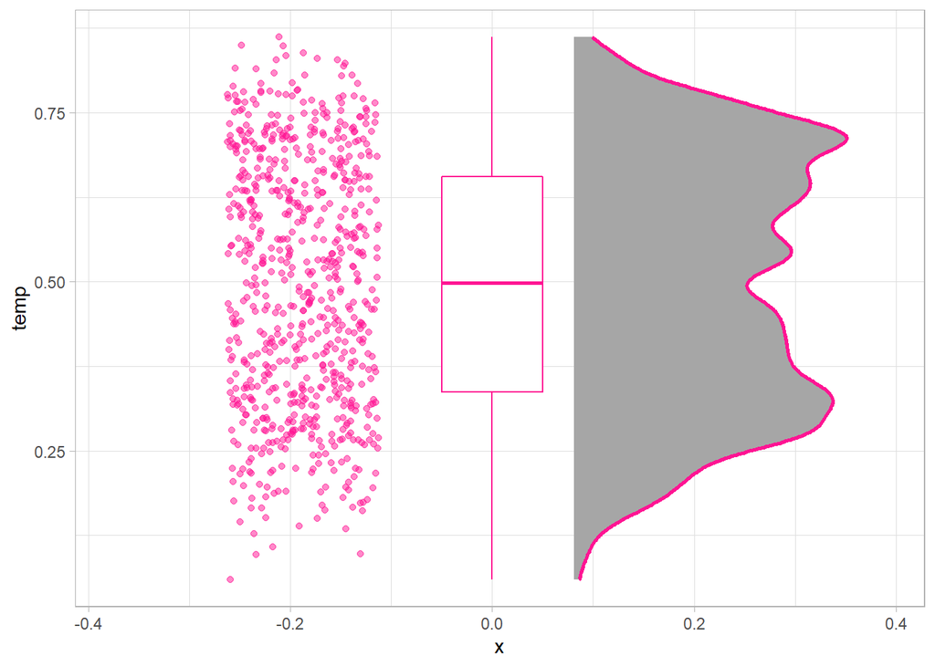

- En esta imagen podemos apreciar una distribucion asimetrica negativa, donde su media es 0.4953848, menor a su mediana que es 0.498333.
- Prodia apreciarse que existen posiblemente datos multimodales, con mas de un pico donde uno de ellos esta por encima de la media y otro por debajo de la media, donde hay temperaturas inferiores a 0.50 o superiores a 0.50.
- La temperatura tiene una desviacion tipica de 0.183051 de variacion con respecto al valor de la media de la temperatura 0.4953848.
- Podemos decir que el IQR, donde estan el 50% de los datos , se encuentra en la franja ente 0.3370835 y 0.6554165.
- No se muestran outliers en el gráfico.

## 3.4 *Variable Sensacion termica (atemp)*

```
##      media  mediana media_winsorizada desviacion_tipica   varianza       IQR
## 1 0.474354 0.486733         0.4768516         0.1629612 0.02655635 0.2707595
##     maximo    minimo        Q1       Q3
## 1 0.840896 0.0790696 0.3378425 0.608602
```

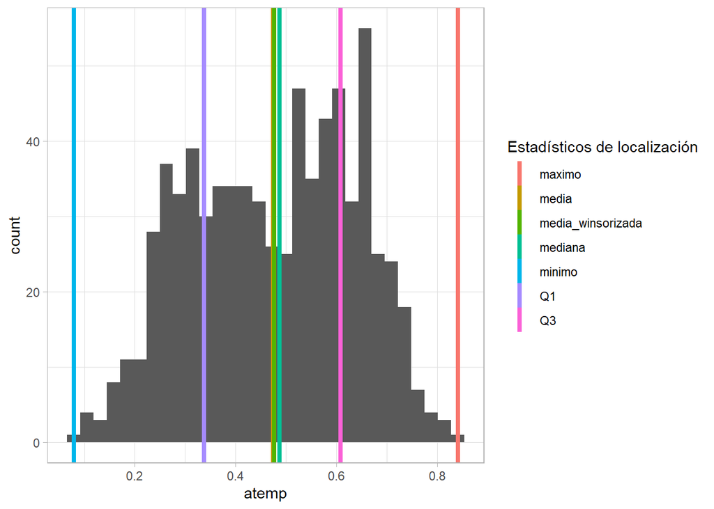

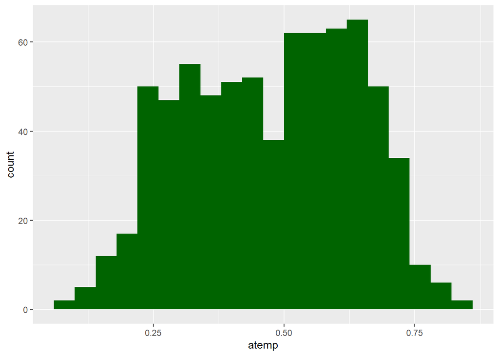

**Grafico Combinado**

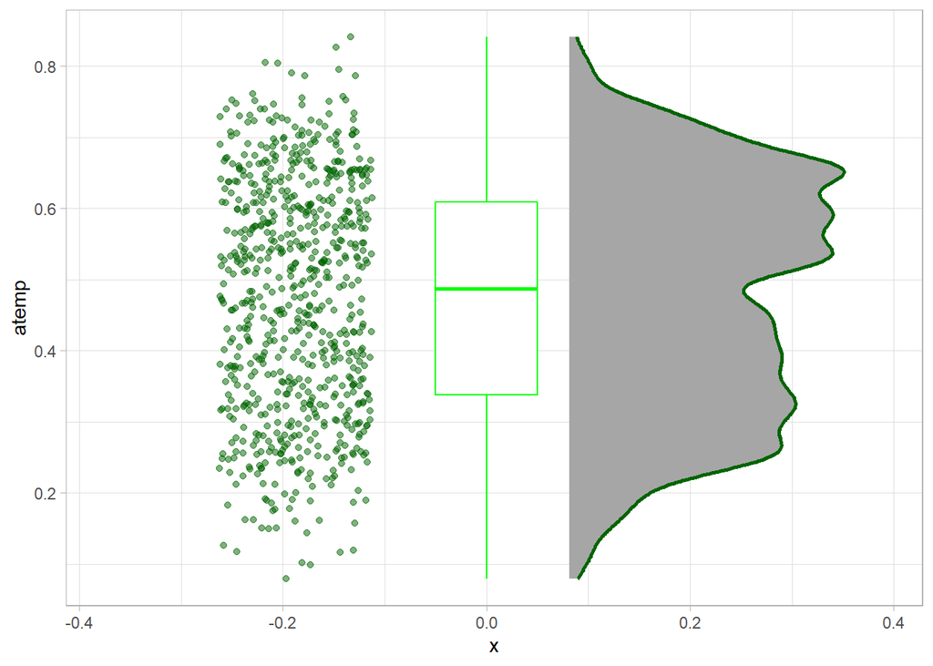

- Prodia apreciarse que existen posiblemente datos multimodales, con mas de un pico, en donde la variable temperatura esta por encima de la media o por debajo, y donde hay sensaciones termicas bajas inferiores a 0.47 y altas superiores a 0.47 aproximadamente.
- En esta imagen podemos apreciar una distribución asimetrica negativa, donde su media es 0.474354, menor a su mediana que es 0.486733.
- La atemp tiene una desviacion tipica de 0.1629612 de variacion con respecto al valor de la media 0.474354.
- Podemos decir que el IQR, donde estan el 50% de los datos , se encuentra en la franja ente 0.3378425 y 0.608602.
- No se muestran outliers en el gráfico.

## 3.5 *Variable Velocidad del viento*

```
##       media  mediana media_winsorizada desviacion_tipica   varianza       IQR
## 1 0.1904862 0.180975         0.1851337        0.07749787 0.00600592 0.0982645
##     maximo    minimo      Q1        Q3
## 1 0.507463 0.0223917 0.13495 0.2332145
```

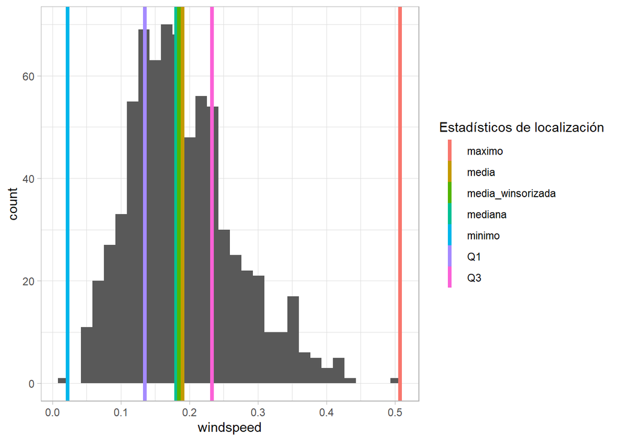

**Grafico Combinado**

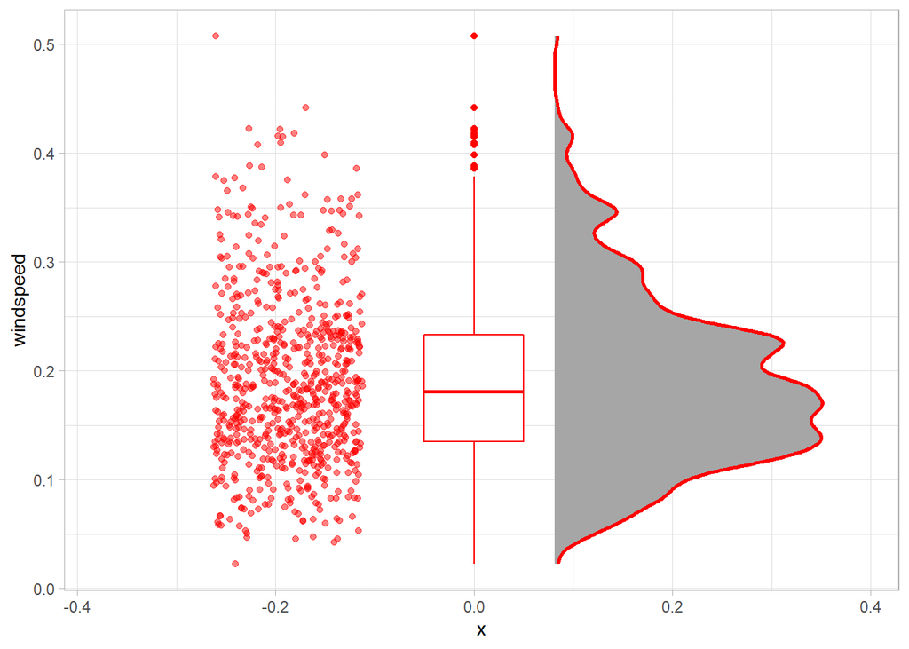

**Deteccion de los outliers del grafico**

```
## $stats
## [1] 0.0223917 0.1349500 0.1809750 0.2332145 0.3781080
##
## $n
## [1] 731
##
## $conf
## [1] 0.1752326 0.1867174
##
## $out
##  [1] 0.417908 0.507463 0.385571 0.388067 0.422275 0.415429 0.409212 0.421642
##  [9] 0.441563 0.414800 0.386821 0.398008 0.407346
```

**Contraste de hipotesis**

- **Hipotesis nula:** Hay distribución normal en los datos
- **Hipotesis alternativa:** No hay distribución normal en los datos

**Nivel de significancia:** alpha = 0.05

```
##
##  Shapiro-Wilk normality test
##
## data:  bikes$windspeed
## W = 0.97123, p-value = 8.426e-11
```

- En este caso se rechaza la hipotesis nula por lo tanto no existe normalidad en la variable Windspeed, ya que el p-value es menor a niveles de significancia.

## 3.6 *Variable registered*

```
##      media mediana media_winsorizada desviacion_tipica varianza    IQR maximo
## 1 3656.172    3662          3641.723          1560.256  2434400 2279.5   6946
##   minimo   Q1     Q3
## 1     20 2497 4776.5
```

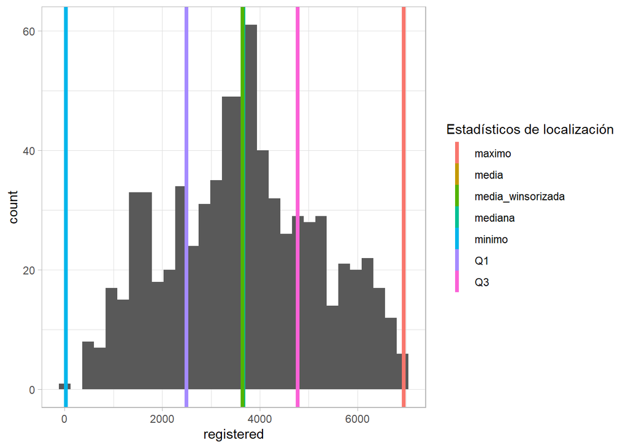

**Grafico Combinado**

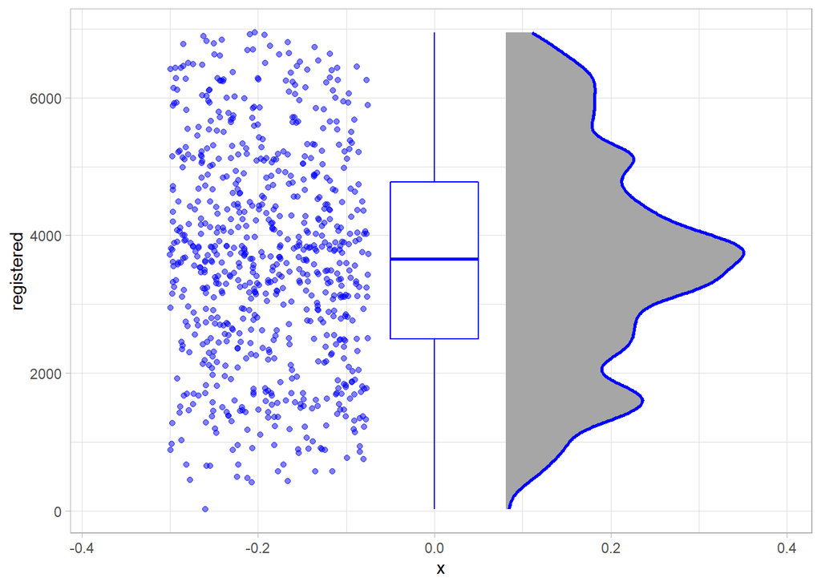

## 3.7 *Variable casual*

```
##      media mediana media_winsorizada desviacion_tipica varianza   IQR maximo
## 1 848.1765     713          744.9504          686.6225 471450.4 780.5   3410
##   minimo    Q1   Q3
## 1      2 315.5 1096
```

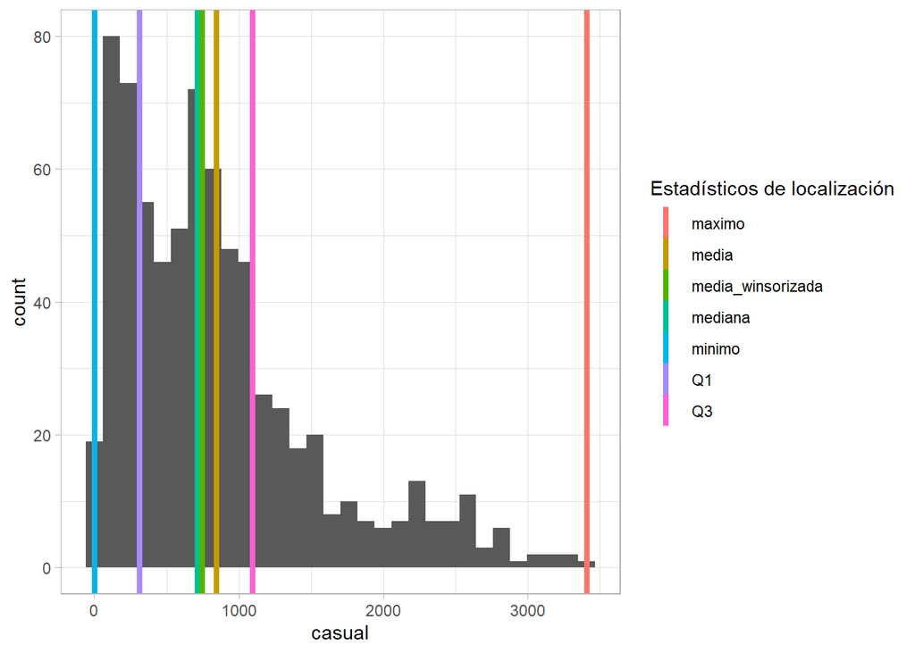

**Grafico Combinado**

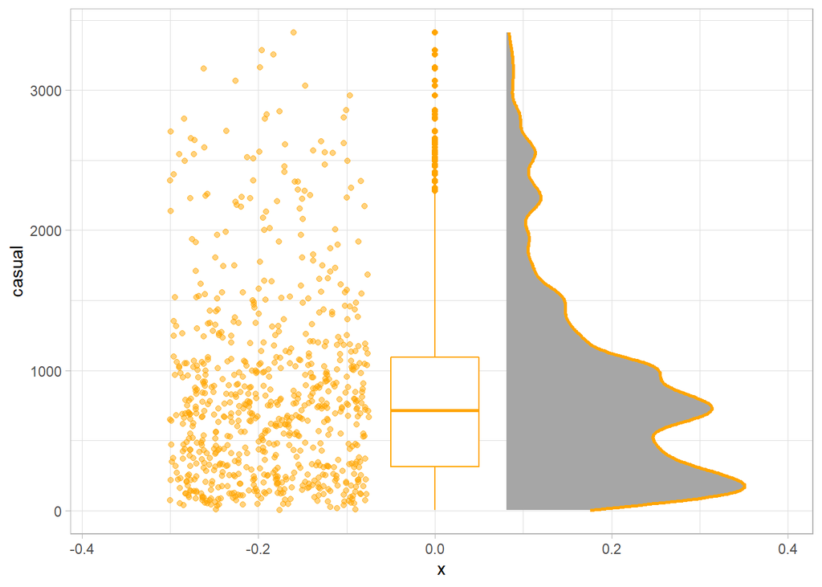

**Deteccion de los outliers del grafico**

```
## $stats
## [1]    2.0  315.5  713.0 1096.0 2258.0
##
## $n
## [1] 731
##
## $conf
## [1] 667.3888 758.6112
##
## $out
##  [1] 2355 2282 3065 2418 2521 2397 3155 2469 2301 2347 3252 2795 2846 2541 2496
## [16] 2622 3410 2704 2855 3283 2557 2795 2494 2708 2963 2634 2657 2551 2562 2355
## [31] 2544 2345 2827 2352 2613 2570 3160 2512 2454 2589 3031 2806 2643 2290
```

# 4 Variables Categoricas

Se realizan transformaciones en las variables categoricas cambiandolas a factor:

- Season
- Year
- Weathersit
- Workingday
- Holiday
- Weekday
- Month

Se comprueba nuevamente el DataFrame, las variables categoricas cambian a tipo de dato “Factor”

```r
str(bikes)
```

```
## 'data.frame':    731 obs. of  16 variables:
##  $ instant   : int  1 2 3 4 5 6 7 8 9 10 ...
##  $ dteday    : chr  "2011-01-01" "2011-01-02" "2011-01-03" "2011-01-04" ...
##  $ season    : Factor w/ 4 levels "Spring","Summer",..: 1 1 1 1 1 1 1 1 1 1 ...
##  $ yr        : Factor w/ 2 levels "2011","2012": 1 1 1 1 1 1 1 1 1 1 ...
##  $ mnth      : Factor w/ 12 levels "Ene","Feb","Mar",..: 1 1 1 1 1 1 1 1 1 1 ...
##  $ holiday   : Factor w/ 2 levels "Working Day",..: 1 1 1 1 1 1 1 1 1 1 ...
##  $ weekday   : Factor w/ 7 levels "Dom","Lun","Mar",..: 7 1 2 3 4 5 6 7 1 2 ...
##  $ workingday: Factor w/ 2 levels "Holiday","Working Day": 1 1 2 2 2 2 2 1 1 2 ...
##  $ weathersit: Factor w/ 4 levels "Good","Moderate",..: 2 2 1 1 1 1 2 2 1 1 ...
##  $ temp      : num  0.344 0.363 0.196 0.2 0.227 ...
##  $ atemp     : num  0.364 0.354 0.189 0.212 0.229 ...
##  $ hum       : num  0.806 0.696 0.437 0.59 0.437 ...
##  $ windspeed : num  0.16 0.249 0.248 0.16 0.187 ...
##  $ casual    : int  331 131 120 108 82 88 148 68 54 41 ...
##  $ registered: int  654 670 1229 1454 1518 1518 1362 891 768 1280 ...
##  $ cnt       : int  985 801 1349 1562 1600 1606 1510 959 822 1321 ...
```

## 4.1 Gráficos de barras para visualizar niveles de las categorías.

Gráficos de barras para visualizar que niveles hay más en cada una de las categorías.

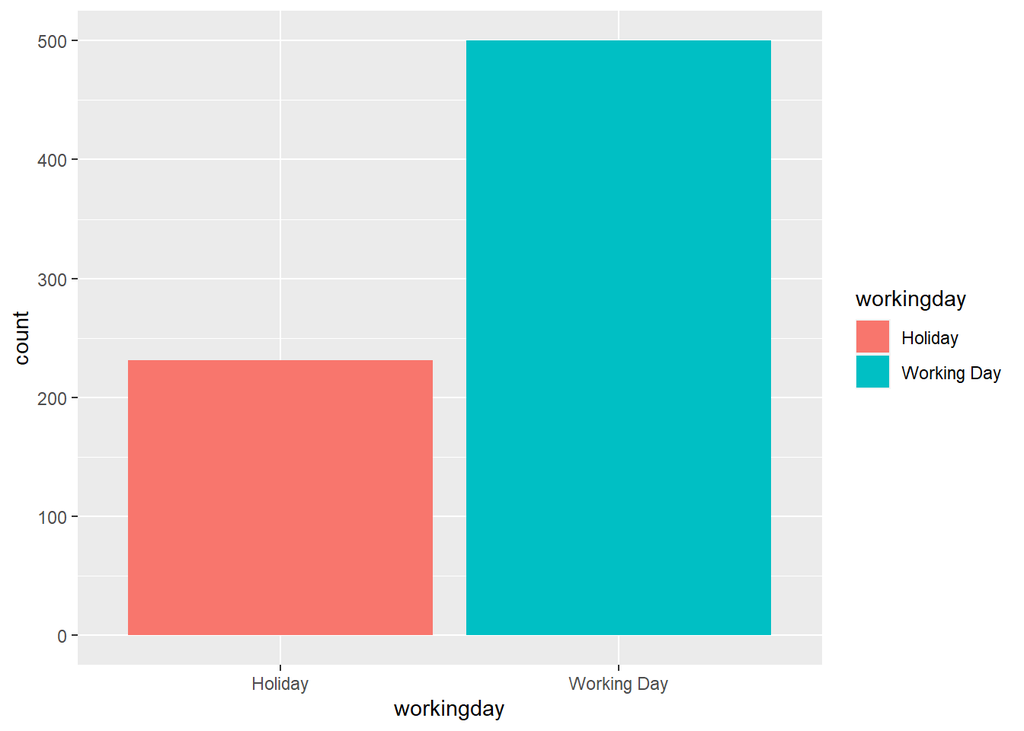

```r
bikes %>% ggplot(aes(workingday, fill = workingday)) + geom_bar()
```

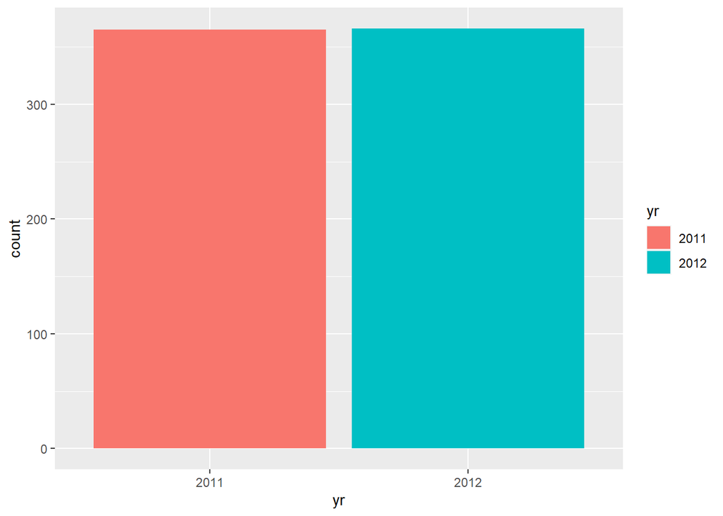

```r
bikes %>% ggplot(aes(yr, fill = yr)) + geom_bar()
```

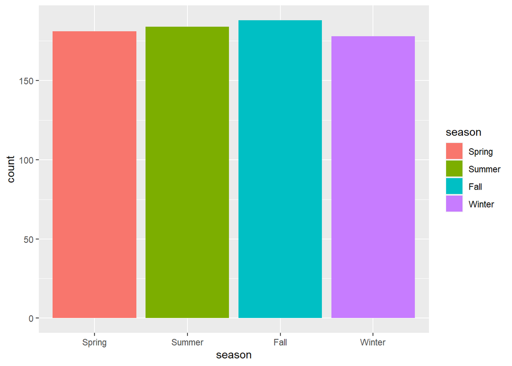

```r
bikes %>% ggplot(aes(season, fill = season)) + geom_bar()
```

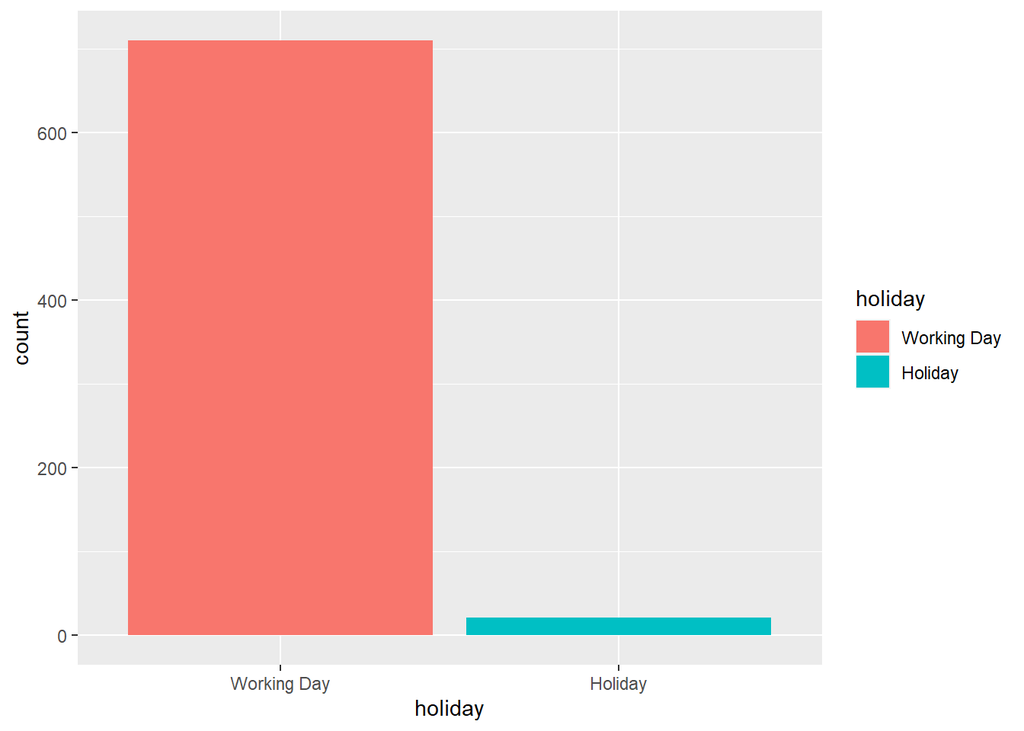

```r
bikes %>% ggplot(aes(holiday, fill = holiday)) + geom_bar()
```

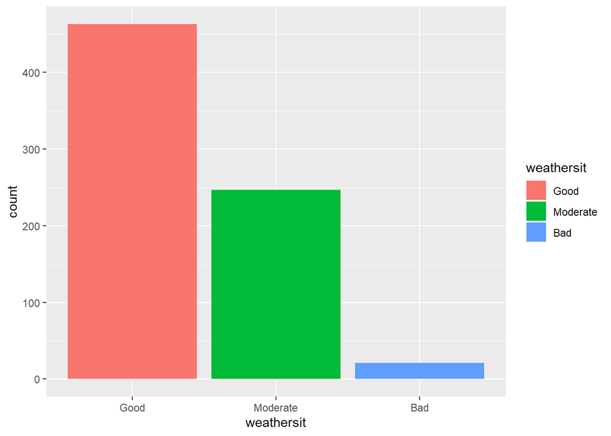

```r
bikes %>% ggplot(aes(weathersit, fill = weathersit)) + geom_bar()
```

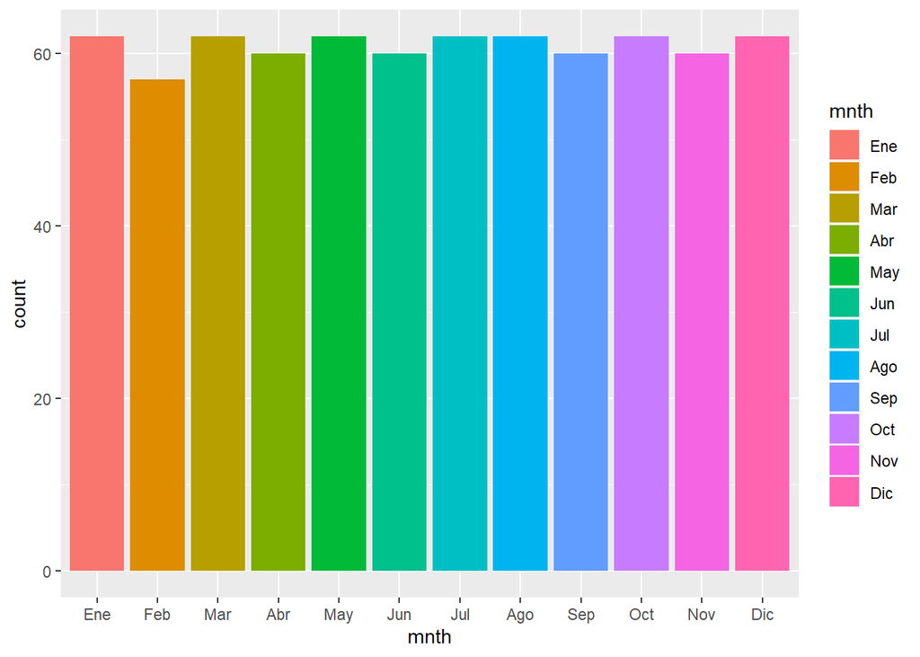

```r
bikes %>% ggplot(aes(mnth, fill =mnth)) + geom_bar()
```

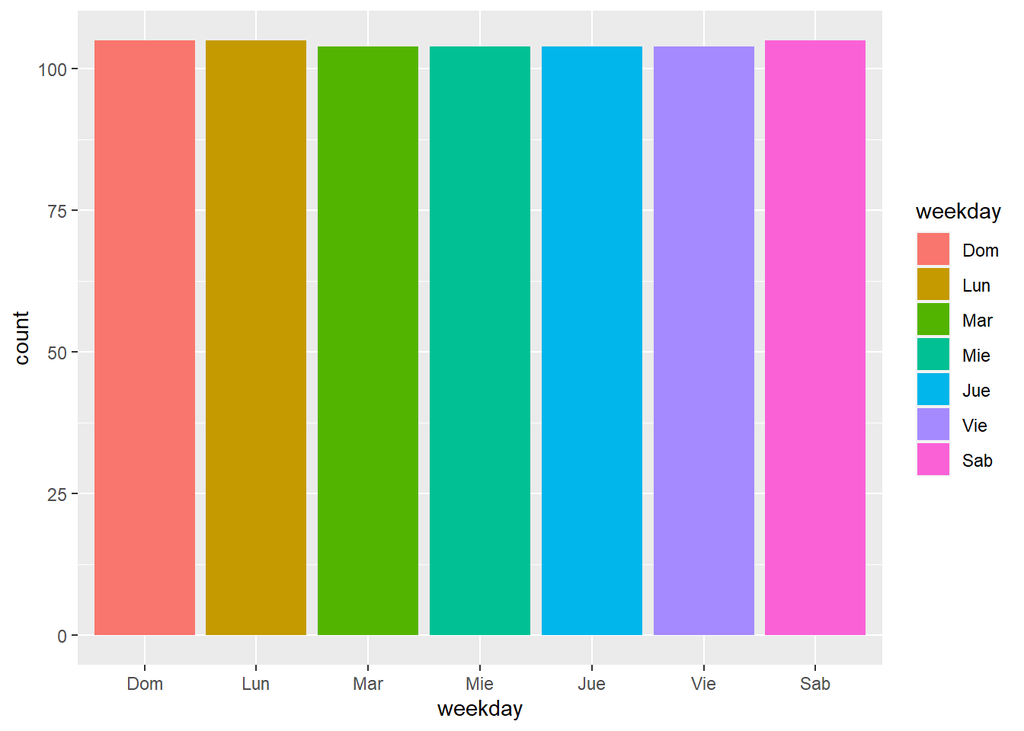

```r
bikes %>% ggplot(aes(weekday, fill= weekday)) + geom_bar()
```

**¿Porque no son interesantes la mayoría de estos gráficos?**

- La mayoria de los graficos no son interesantes porque se observan solo los niveles de cada variable categorica, donde lo interesante seria cruzarla con otra variable.

## 4.2 Scatterplot de la variable count

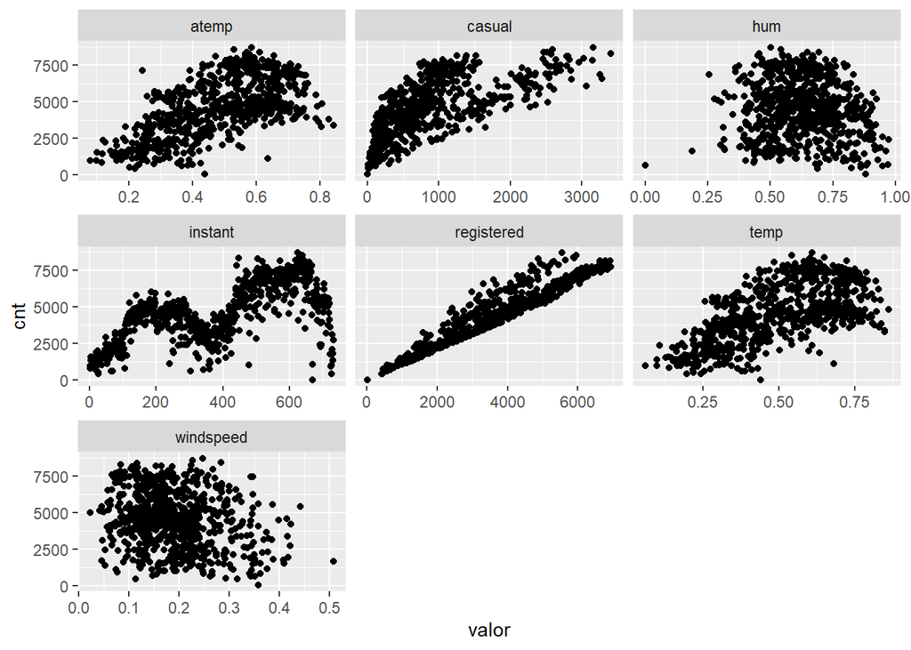

## 4.3 Realizar un scatterplot de cada variable contra count. ¿Que observas?

- Al aumentar los usuarios registrados aumentan los alquileres de las bicicletas
- Cuando Windspeed se incrementa, vemos que disminuye levemente la cantidad de alquileres, ya que observamos una pequeña pendiente negatia
- Cuando la temperatura y atemp, pareciera que existieran dos grupos de preferencias en el alquiler de bicicletas con temperaturas superiores e inferiores a la media.
- Parece un comportamiento logaritmico por lo que podemos decir que los usuarios casuales aumentan hasta cierto punto con una concentracion superior que luego disminuye.

## 4.4 ¿Crees probable alguna interacción en base a los gráficos?

- Las variables Casual y Registered pueden tener alguna relacion ya que visualmente con respecto al alquiler de bicicletas tiene una tendencia creciente
- Las variables temp y atemp pueden tener una relacion al tener un comportamiento o una forma muy similar.

## 4.5 Métodos de correlación

**Utiliza distintos metodos de correlacion y razona sobre los resultados.**

### 4.5.1 Correlación de Pearson

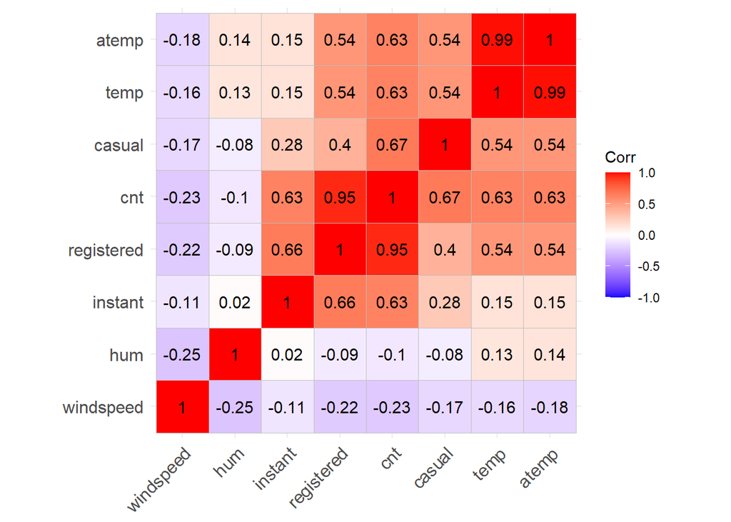

### 4.5.2 Correlación de Spearman

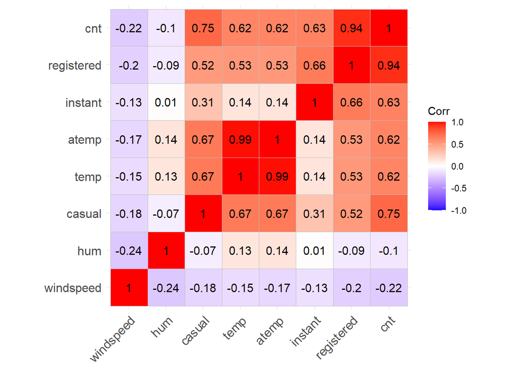

### 4.5.3 Correlación de Kendall

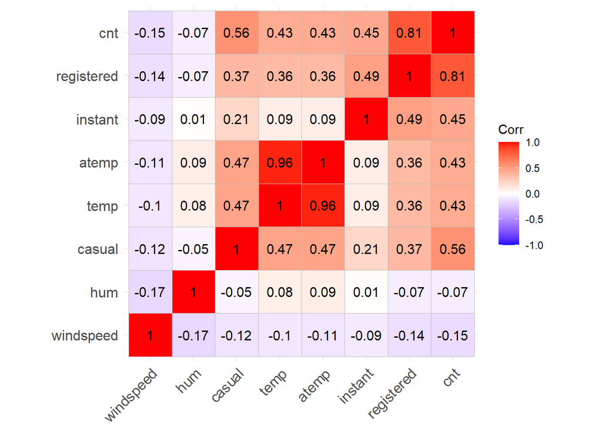

**PEARSON**

- Se utilizan para evaluar la relacion lineal entre dos variables continuas. Es un metodo sensible a los outliers. Las condiciones para utilizar este estimador son que los datos o variables aleatorias sean continuas y medirá bien la relación cuando los datos tengan una relación lineal. Por tanto, este coeficiente nos ayduará a detectar relaciones lineales o aproximadamente lineales.
- Vemos que la relación no es lineal, pero con algunas variables tiene algún tipo de aproximación lineal ya que marca algo de correlación.
- Tambien vemos que algunas variables no tienen un desarrollo lineal porque da una correlación muy cercana a 0.

**Spearman y Kendall**

Kendall y Spearmen se utilizan para datos no parametricos, cuando la distribucion de los datos es desconocida o no satisface la condicion de normalidad.

- Spearman se utiliza para evaluar la relacion monotona entre dos variables continuas u ordinales, es decir, que las variables tiendan a cambiar al mismo tiempo aunque no necesariamente a un ritmo constante. Se observa el ajuste de la correlacion con respecto a pearson, una vez los datos son ordenados y reemplazados por su respectivo orden.
- Kendall utiliza tambien la ordenación de los datos. Es recomendable cuando se dispone de pocos datos y muchos de ellos ocupan la misma posición en el rango, es decir, cuando hay muchas ligaduras.

Analizamos la correlación de las variables de estudio:

- Existe una alta correlacion positiva entre la cantidad de bicicletas alquilada (cnt) y los usuarios registrados (registred)
- Existe una correlacion media entre cantidad de bicicletas alquilas y los usuarios casuales
- Existe una correlacion negativa entre la cantidad de biciletas alquiladas y la velocidad del viento.
- Existe una alta correlación positiva entre la temperatura(temp) y la sensación térmica(atemp)
- Existe una correlacion negativa entre la humedad y la velocidad del viento.

## 4.6 Relaciones temporales

### 4.6.1 Las bicis se alquilan más los fines de semana o entre semana

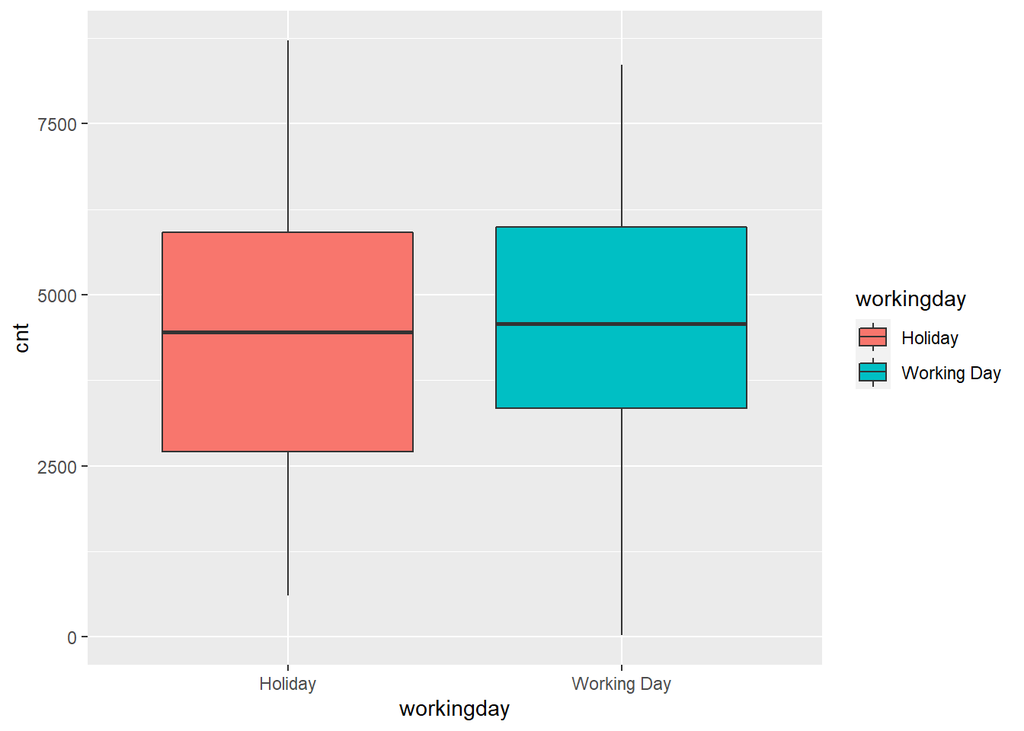

```r
  bikes %>%
    ggplot() +
    geom_boxplot(aes(x = workingday, y = cnt, fill = workingday))
```

- En ambos boxplot se muestra la mediana muy similar
- El 50% de los datos (la caja del boxplot) en Workingday es mas elevado con respecto al 50% de los datos(la caja del boxplot) en holiday
- Entre la mediana y el Q1 se encuentran mas observaciones que entre la mediana y el Q3 en Holiday
- Los valores superiores de alquiler se encuentran en Holiday
- Los valores inferiores de alquiler se encuentran en workingday
- La caja de holiday es mas grande porque tiene concentrada la mayor cantidad de datos dentro del 50%

**¿Hay diferencia estadística con un α=0.05 para asegurar que hay menos alquileres en fin de semana que entre semana?**

**Hipotesis nula: $H_{0}:$** Promedio de alquileres de bicis fines de semana es mayor o igual que entre semana

Se añade la variable **weekend** donde se utiliza un condicional de la variable weekday para saber si es fin de semana (Sabado o Domingo), ya que en la variable workingday existen algunos lunes como festivos.

- “SI” si es sabado o domingo
- “No” si es un dia entre lunes y viernes.

```r
bikes$weekend <- ifelse(bikes$weekday == "Dom" | bikes$weekday == "Sab", "Si","No")
```

```r
t.test(bikes$cnt[bikes$weekend == "Si"],
       bikes$cnt[bikes$weekend == "No"],
       alternative = "less")
```

```
##
##  Welch Two Sample t-test
##
## data:  bikes$cnt[bikes$weekend == "Si"] and bikes$cnt[bikes$weekend == "No"]
## t = -0.98373, df = 361.39, p-value = 0.163
## alternative hypothesis: true difference in means is less than 0
## 95 percent confidence interval:
##      -Inf 108.8113
## sample estimates:
## mean of x mean of y
##  4389.686  4550.566
```

- El p-value es mayor al nivel de significacia (α=0.05), porlo que no se rechaza la hipotesis nula por lo tanto no se prueba que los alquileres de bicis los fines de semana son menor que entre semana, afirmacion que se realiza con un nivel de confianza del 95%.

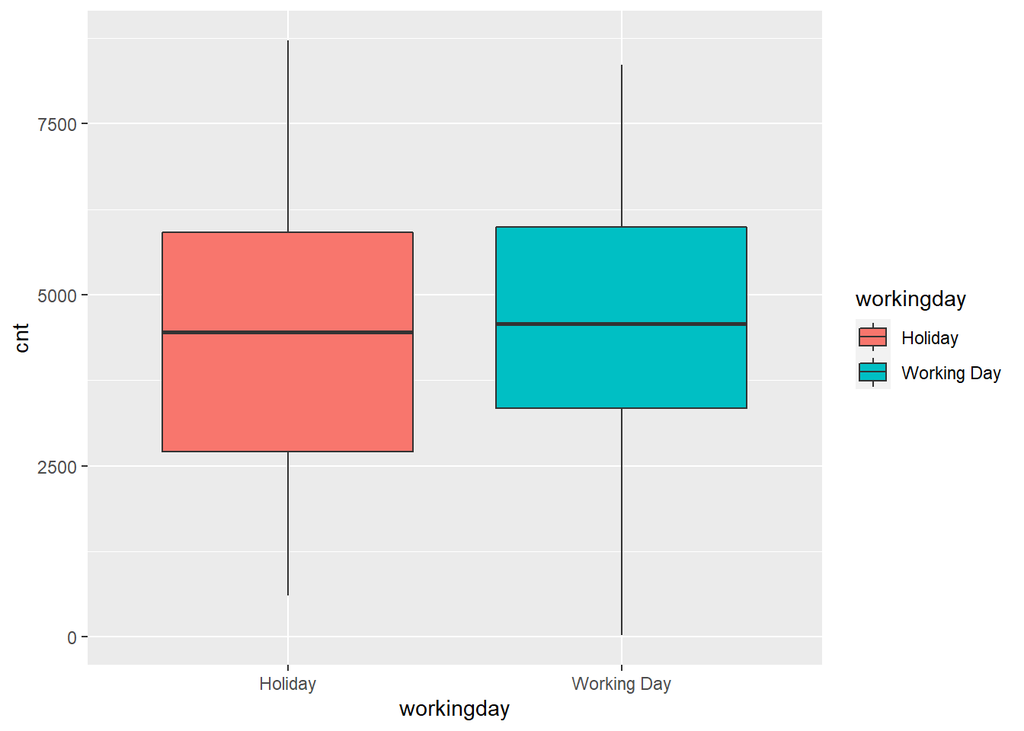

```r
  bikes %>%
    ggplot() +
    geom_boxplot(aes(x = workingday, y = cnt, fill = workingday))
```

### 4.6.2 Dias de la semana que mas bicis se alquilan

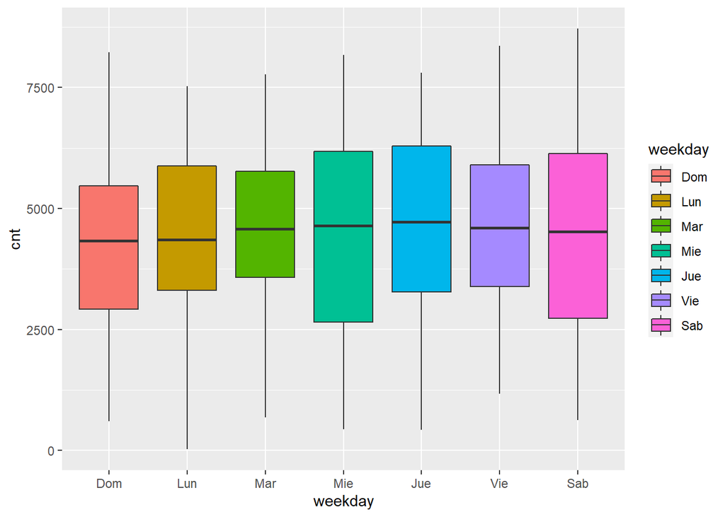

```r
  bikes %>%
    ggplot() +
    geom_boxplot(aes(x = weekday, y = cnt, fill = weekday))
```

- Podemos observar que el Sabado es el dia donde mas se han alquilado bicis
- La mediana mas alta es los jueves
- Los valores mas alto de alquileres se encuentran los dias Sabados
- Los valores mas bajos de alquileres son los dias Lunes
- La caja mas grande es el Miercoles porque este dia la concentracion de los datos es mayor dentro del 50% de los datos

### 4.6.3 Temporada donde se alquilan mas bicis

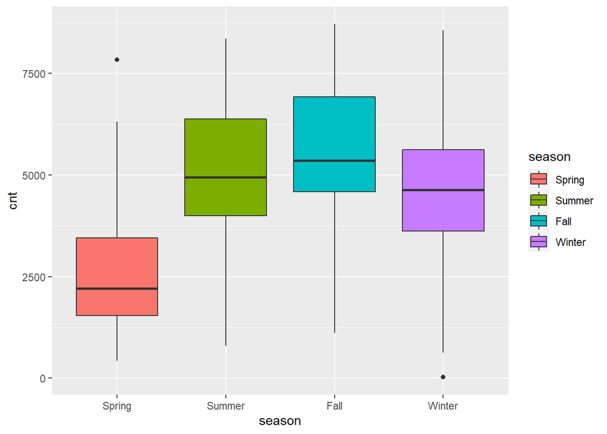

```r
  bikes %>%
    ggplot() +
    geom_boxplot(aes(x = season, y = cnt, fill = season))
```

- Podemos observar que en la temporada en otoño se encunetra el valor de alquiler de bicis mas alto.
- Podemos observar que en la temporada de primavera se encuentra un valor oulier superior que indica que no es normal que alquilen esa cantidad de 7836 bicis en primavera, siendo normal para el resto de temporadas ya que sus bigotes llegan a esa altura aproximada.
- Se muestra un outlier negativo en la temporada de invierno donde se realizaron solo 22 alquileres de bicis, ademas al analizar el dataframe vemos que era un dia lunes laborable y el tiempo era considerado malo.
- Podemos añadir que las distribuciones de las cajas son asimetricas, y la mas cerca de parecerse a una normal es “winter”
- La mediana de las temporadas Spring, Summer y Fall, se encuntran desplazadas hacia abajo, lo que indica que el 50% de los datos dentro de la caja estan concentrados por encima de la mediana, mientras que en Winter apreciamos un ligero desplazamiento hacia arriba, lo que indica lo contrario, es decir, el 50% de los datos se concentra por debajo de la mediana.

## 4.7 Interacciones

**Interacciones:** *tanto en la relación con registered como con temp hay una interacción clara. Encuentra estas variables y representalo de un modo visual.*

Regresión con modelo lineal, con la variable “Cnt” como dependiente y “Registered” y “temp” como explicativas:

```r
model <- lm(cnt ~ registered + temp, data = bikes)
summary(model)
```

```
##
## Call:
## lm(formula = cnt ~ registered + temp, data = bikes)
##
## Residuals:
##    Min     1Q Median     3Q    Max
## -850.0 -365.6 -170.7  131.8 2508.2
##
## Coefficients:
##              Estimate Std. Error t value Pr(>|t|)
## (Intercept) -248.4525    64.8888  -3.829  0.00014 ***
## registered     1.0633     0.0161  66.047  < 2e-16 ***
## temp        1746.4737   137.2231  12.727  < 2e-16 ***
## ---
## Signif. codes:  0 '***' 0.001 '**' 0.01 '*' 0.05 '.' 0.1 ' ' 1
##
## Residual standard error: 571.2 on 728 degrees of freedom
## Multiple R-squared:  0.9133, Adjusted R-squared:  0.9131
## F-statistic:  3834 on 2 and 728 DF,  p-value: < 2.2e-16
```

Como encontramos que las gráficas de correlación contra el alquiler de bicicletas con la temperatura y los usuarios registrados estaban relacionadas, creamos un modelo lineal y encontramos lo siguiente:

- El modelo con estas variables introducidas como predictores es capaz de explicar el 91.33% de la variabilidad observada en el alquiler de las bicicletas(R-squared: 0.9133).
- Podemos decir que ambas variables son significativas, ya que su nivel de significancia es muy cercano al 0 *** y con p-value muy bajo. Ademas, el modelo se considera significativo ya que el test F muestra un p-value de 2.2e-16.
- Los usuarios registrados en media alquilan 1.0633 bicis.
- La temperatura influye en la media del aquileres de bicicleta en un 1746.47

Sin embargo, al verificar el gráfico de residuos y el gráfico de QQ, podemos ver que los residuos tienen un patrón y no están distribuidos normalmente, lo que significa que el modelo lineal no se ajusta tan bien a los datos.

**Grafico**

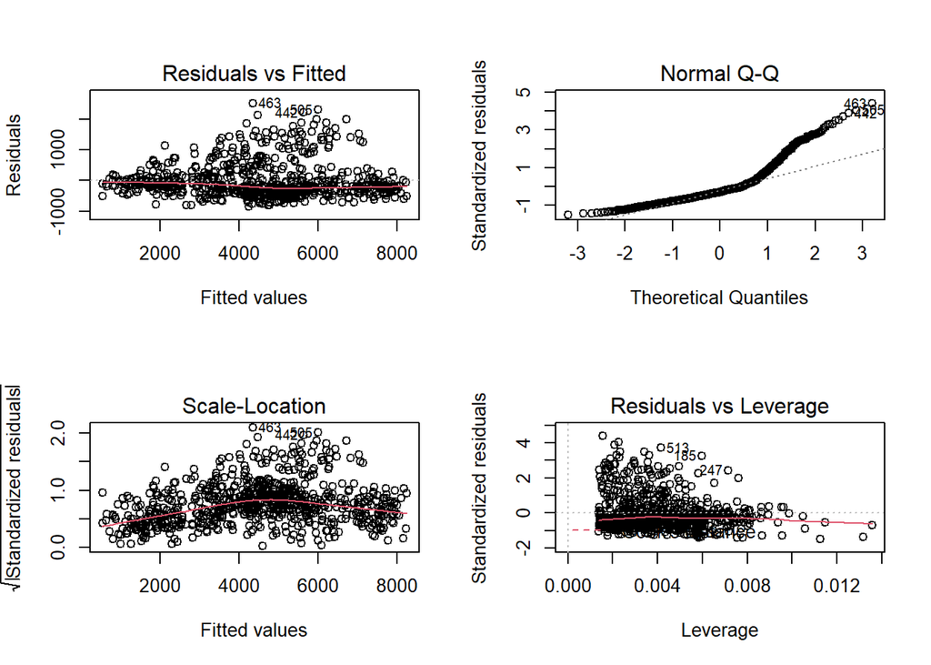

```r
par(mfrow = c(2, 2))
plot(model)
```

## 4.8 Habitos de consumo con respecto al año anterior

**¿Ha cambiado el hábito de consumo de los clientes de un año a otro en cuanto a coger la bici los fines de semana?**

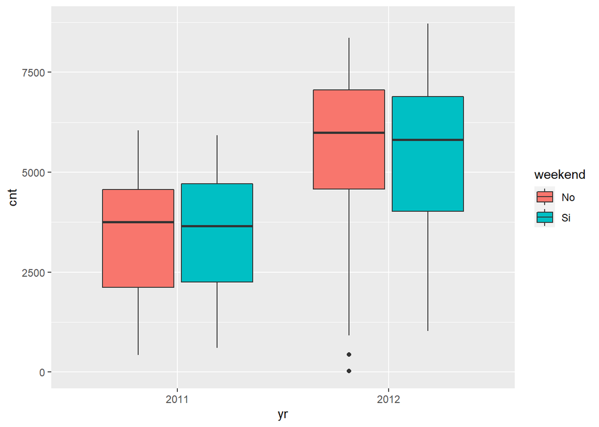

```r
  bikes %>%
    ggplot() +
    geom_boxplot(aes(x = yr, y = cnt, fill = weekend))
```

**NOTA:** *Recordemos que creamos la variable weekend con valor “Si” para fines de semana y “No” para dias de la semana entre lunes y viernes*

Podemos observar que el habito de alquiler de los clientes de un año con respecto al otro cambia, ya que se evidencia lo siguiente:

- Un incremento de los valores mayores de alquileres de bicis tanto en fines de semana como entre semana, es decir el valor de los bigotes es superior con respecto a 2011.
- Podemos observar que las cajas se desplazan hacia arriba, lo que indica que el 50% de los datos tienen un valor mayor en alquileres con respecto al año anterior.
- Al desplazarse la caja, vemos que tambien se desplaza la mediana, la cual en ambos casos se encuentra desplazada hacia la parte superior de la caja, lo que indica que dentro del 50% de los datos, la mayoria esta concentrada debajo de la media.

# 5 Problema de Probabilidad

Dos equipos jugarán un partido al mejor de 7 (el partido terminará tan pronto como cualquiera de los equipos haya ganado 4 juegos). Cada juego termina con una victoria para un equipo y una derrota para el otro equipo.

Suponga que cada equipo tiene la misma probabilidad de ganar cada juego y que los juegos que se juegan son independientes.

Encuentre la media y la varianza del número de juegos jugados.

### 5.0.1 Funcion para el experimento

```r
partido2<- function(){
    gana_teamA = c()
    juego=0
    rondas = 0
    while (juego < 4) {
      nuevo_juego = sample(0:1, 1)
      gana_teamA = c(gana_teamA , nuevo_juego)
      juegoA = sum(gana_teamA)
      juegoB = length(gana_teamA[gana_teamA==0])
      juego=max(juegoA,juegoB)
      rondas = rondas + 1
    }
 #   return( list(juegoA,juegoB,rondas) )
    return( rondas )
  }

partido2()
```

```
## [1] 7
```

### 5.0.2 Repetimos muchas veces el experimento.

```r
set.seed(1234)
  numero_partidos = replicate(100000, partido2())
```

Media de numero de partidos

```r
    media = mean(numero_partidos)
    print(media)
```

```
## [1] 5.80874
```

Varianza de numero de partidos

```r
varianza = var(numero_partidos)
print(varianza)
```

```
## [1] 1.03075
```

Desviacion Tipica

```r
desviacion_tipica = sd(numero_partidos)
print(desviacion_tipica)
```

```
## [1] 1.015259
```

### 5.0.3 Boxplot del numero de partidos

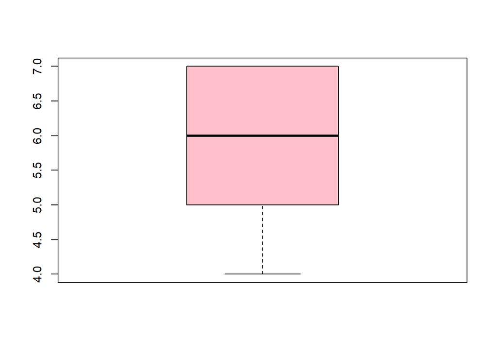

```r
boxplot(numero_partidos, col = "pink")
```

```r
quantile(numero_partidos, prob=c(0,0.25,0.5,0.75,1))
```

```
##   0%  25%  50%  75% 100%
##    4    5    6    7    7
```

Maximo de numero de partidos

```r
  max(numero_partidos)
```

```
## [1] 7
```

### 5.0.4 Histograma del numero de partidos

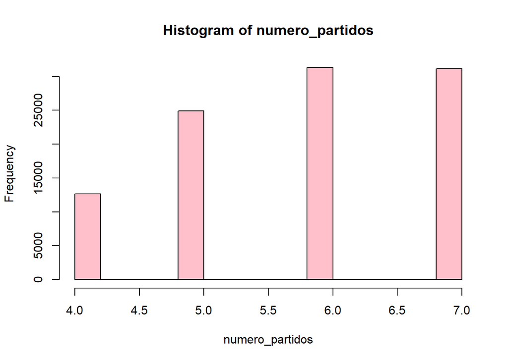

```r
hist(numero_partidos, col = "pink")
```